# mphil-public-communication-brief – Sun and Sea

Seaweed Farming in Jamaica

*“Seaweed is a billion dollar industry around the world, I’m ready to try and help Jamaica get a piece of that pie. “*

My name is Matthew-Pierre Rogers. I’m a graduate student at UWI mona and my Research is focusing on figuring out what are the best local seaweeds to grow and the best ways to grow them here.

## Untapped Potential

Seaweeds are already used in a ton of places you probably don’t realise or think about. In Jamaica, we know about Irish Moss. The rest of the Caribbean has similar drinks, but it’s not the only thing seaweeds can be used for.

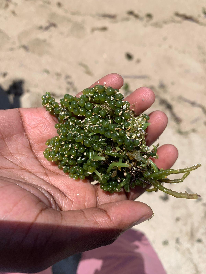

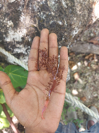

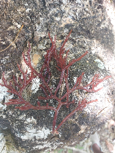

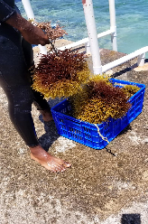

Sea Grapes. These are farmed, eaten in Asia, and grow underwater in Jamaica.  
2 kinds of Gracilaria, one of the seaweeds used to make Irish Moss in Jamaica  
Kappaphycus, The most popular seaweed farmed in the tropics, and the only one Jamaica is looking into farming currently

There are also tonnes of other seaweeds that are used elsewhere in the world; for food, medicine, gels and even plastics.

## The Plan

My research will look at what local species of seaweed we already have growing in Jamaica. After these are found, species that are already used elsewhere will be grown locally. I will see what grows best and what grows fastest. Then I’ll test the seaweeds to see how well they would be able to be used for things like food and gels.

If all goes as well, when the research is done, I will have a list of what can be done with our local seaweeds, which grow the fastest, and the best ways to farm them locally. My hope is that it kickstarts seaweed farming in Jamaica, and a couple businesses making seaweed products too. It will be another way for people to grow food and make a living from our sea. Imagine a whole new industry, growing on our coasts, feeding and earning for Jamaican people!

## Follow the Journey

I’ve made the decision to document the process along the way. I want the science to be sharable and understandable for anyone. To do that, I’m making an effort to share and carry out (some of the research) in public.

Follow my research journey [on twitter](https://x.com/Rogers_M_P) or over on [my blog](https://mparogers.com/).